# R u Ready? HS2025 | Psychologie der Digitalisierung - Einheit 9

Sandra Grinschgl, Aaron Friedli, Lars Schilling

## R u Ready? Reproduzierbare Datenaufbereitung und -analyse mit R

HS 2025  
**LV-Leitung**: Dr. Sandra Grinschgl / MSc. Aaron Friedli  
**Tutor**: BSc. Lars Schilling  
**9. Einheit**, 12.11.2025

## Heute:

[interactive chart not shown]

## Besprechung Hands On Block 4 & Hausübung 1:

- Scheint sehr gut gelungen zu sein!

**Probleme beim Einlesen –> Keine NAs sondern nur leere Zellen –> Andere Funktionen als read_delim genutzt.**

```r
data <- read_delim("raw/fake_bfi_dataset.csv", delim = ";")

bfi_10 <- drop_na(data)
```

## Besprechung Hausübung 1:

**Effizienter Code Beispiel aus den Musterlösungen mit `across()`**

Argument 1: cols = –> welche colums sollen bearbeitet werden

Argument 2: .fns 👉 Welche Funktion wenden wir auf die cols. an.

```r
data_bfi_recoded <- clean_data_bfi_10 |>
  mutate(
    across(
      c(bfi_extra_1_r, bfi_agree_2_r, bfi_consc_2_r, bfi_neuro_2_r, bfi_open_2_r),
      ~ case_when(
        . == 1 ~ 5,
        . == 2 ~ 4,
        . == 3 ~ 3,
        . == 4 ~ 2,
        . == 5 ~ 1
      )
    )
  )

#Sparsamere Alternative

data_bfi_recoded <- clean_data_bfi_10 |>
  mutate(
    across(ends_with("_r"), ~ 6 - .)  # 6- Minus current Value .
  )


data_bfi_recoded <- clean_data_bfi_10 |>
  mutate(
    across(ends_with("_r"), function(x) 6 - x) # Umgeschrieben
  )
```

[Anonyme Funktionen](https://coolbutuseless.github.io/2019/03/13/anonymous-functions-in-r-part-1/)

## Hausübung 1

Falls eure gerenderten Skripte bei den Peer-Partnern nicht richtig angezeigt werden 👉 Im Header des Quarto-Dokuments

`embed-resources = true`

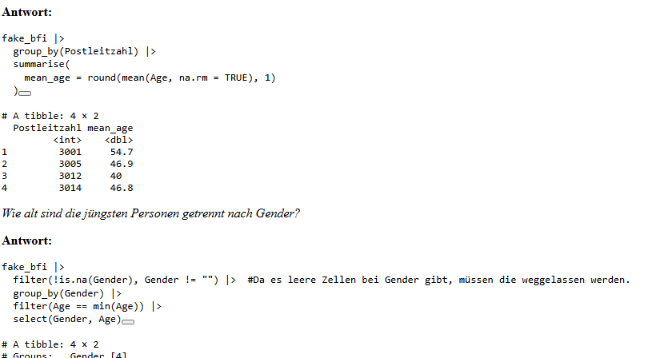

## Genzplyr 💅

**Falls euch die `dplyr()` Funktionen zu Öde sind 😄[genzplyr](https://hadley.github.io/genzplyr/) - Hadley Wickham**

[figure not shown]

```r
library(genzplyr)

penguins |>
  vibe_check(island, species, sex)
  yeet(island == "Biscoe")
```

## Heute:

- Wide - Long
- Datenqualität (Schiefe, Kurtoseis, Ausreisser, Skalenreliabilität)

## Wide to Long Tranformation:

- Wide: Jede Zeile bezieht sich auf eine Person und beinhaltet alle Messzeitpunkte
- Long: Pro Messung (repeated measures) eine Zeile, Personen strecken sich über mehrere Zeilen hinweg.

👉 Long Format is häufig benötigt für Analysen mit einem **repeated measures** Faktor

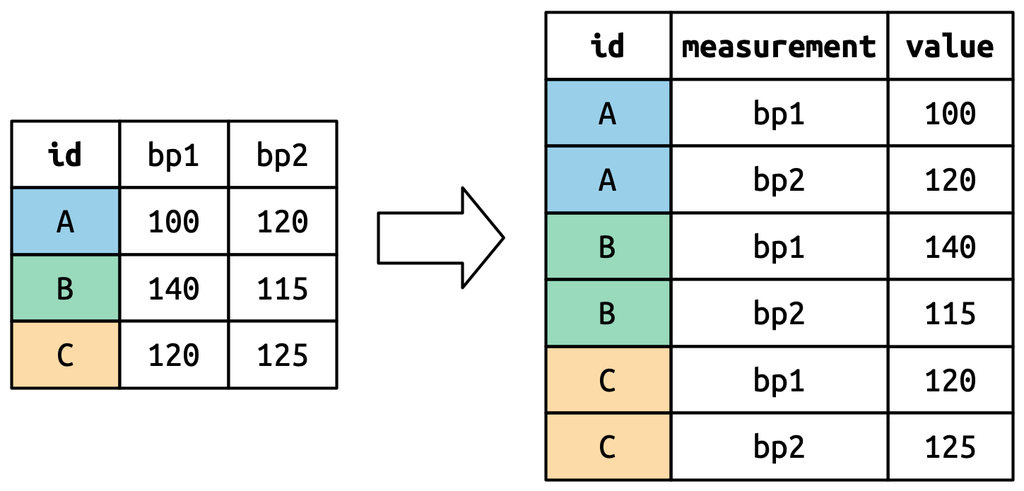

## **Transformation wide to long**

**Wie müssen wir den folgenden Datensatz transformieren, um ihn ins long Format zu bekommen?**

| *id* | *messzeitpunkt_t1* | *messzeitpunkt_t2* | *messzeitpunkt_t3* |
| --- | --- | --- | --- |
| 1 | 10 | 14 | 18 |
| 2 | 12 | 15 | 17 |
| 3 | 9 | 13 | 15 |
| 4 | 11 | 12 | 16 |

**Argumente:**

- **`cols`** 👉Welche Variablen sollen transformiert (also zusammengestapelt) werden?
- **`names_to`**👉 Wie heisst die neue Variable, die den Messzeitpunkt (oder generell den ursprünglichen Spaltennamen) enthält?
- **`values_to`**👉 Wie heisst die neue Variable, in der die Werte aus den ursprünglichen Spalten gespeichert werden?

```r
df_long <- df_wide |>
  pivot_longer(
    cols = starts_with("messzeitpunkt_t"),
    names_to = "messzeitpunkt",
    values_to = "score"
  )

df_long[1:3, 1:3]
```

```
# A tibble: 3 × 3
     id messzeitpunkt    score
  <int> <chr>            <dbl>
1     1 messzeitpunkt_t1    10
2     1 messzeitpunkt_t2    14
3     1 messzeitpunkt_t3    18
```

## Long to Wide mit `pivot_wider()`

**Argumente:**

- **`names_from`** 👉Die Werte aus dieser Spalte (`messzeitpunkt`) werden wieder zu Spaltennamen.
- **`values_from`**👉Die Werte aus dieser Spalte (`score`) füllen die neu entstandenen Spalten.

```r
df_wide_again <- df_long |>
  pivot_wider(
    names_from = messzeitpunkt,
    values_from = score
  )

df_wide_again[1:4, 1:4]
```

```
# A tibble: 4 × 4
     id messzeitpunkt_t1 messzeitpunkt_t2 messzeitpunkt_t3
  <int>            <dbl>            <dbl>            <dbl>
1     1               10               14               18
2     2               12               15               17
3     3                9               13               15
4     4               11               12               16
```

## Paket tidyr

[figure not shown]

`pivot_longer()` und `pivot_wider()` stammen aus dem Paket tidyr - Teil des tidyverse

[Cheatsheet tidyr](https://rstudio.github.io/cheatsheets/tidyr.pdf)

Umgang mit fehlenden Werten: `drop_na()`, `replace_na()` stammen auch aus tidyr

## Wichtige Funktionen Datenaufbereitung:

aus [Einführung in R, Kapitel 4.1](https://methodenlehre.github.io/einfuehrung-in-R/chapters/04-tidyverse.html)

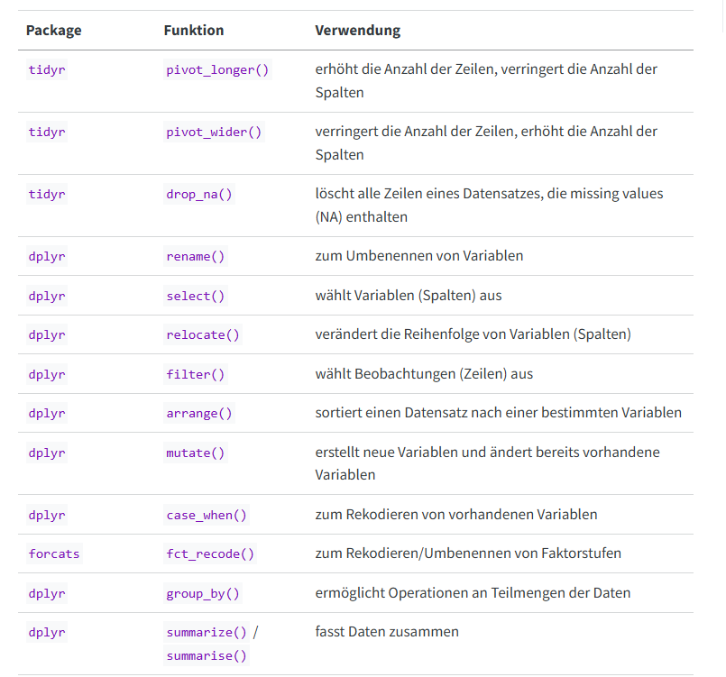

## Hands On!

- Code korrigieren / verbessern
- Long Transformationen

# Datenqualität:

- Normalverteilung der Residuen
- Schiefe /Skewness
- Kurtosis / Kurtosis
- Skalenreliabilität
- Ausreisseranalyse

Paket: **psych**

## Skewness / Kurtosis

**Schiefe / Skewness: Funktion `skew()`**

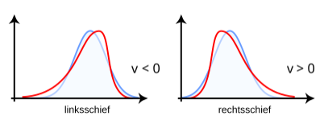

**Kurtosis / Wölbung: Funktion `kurtosi()`**

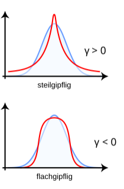

## Residuen

Die Normalverteilung der Residuen ist eine Voraussetzung für viele statistische Tests.

Mögliche Arten, diese Annahme zu ueberprüfen:

- **Visuelle Verfahren** (z.B. QQ-Plot)
- **Formale Tests** (z. B. Shapiro-Wilk) –> “veraltete” Methode

Visuelle Verfahren werden heute meist bevorzugt, da sie weniger sensitiv gegenüber Stichprobengrössen sind.

Allerdings gilt: Verletzungen der Normalitätsannahme sind in der Praxis oft weniger problematisch als angenommen. Sollte es problematisch sein, kann auf nichtparametrische Verfahren ausgewichen werden.

## Normalität der Residuen

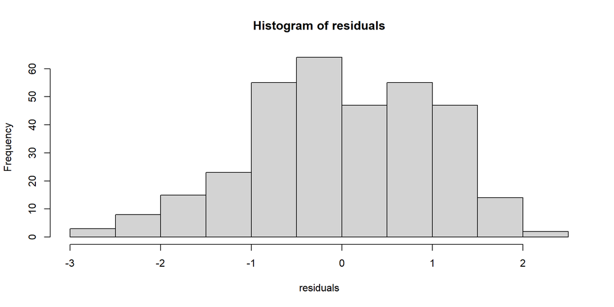

## Residuen: QQ-Plot

**Zweck:** QQ-Plots prüfen, ob die Daten einer theoretischen Verteilung (z. B. Normalverteilung) folgen.

- **X-Achse:** **Theoretische Quantile**
- **Y-Achse:** **Beobachtete (empirische) Datenquantile**

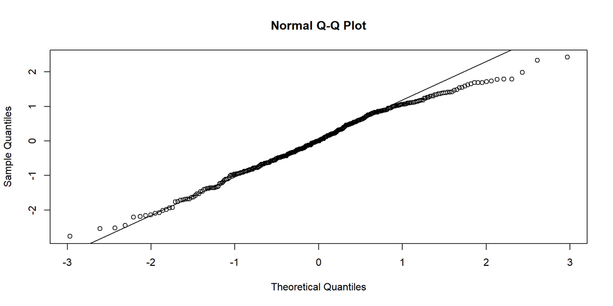

## Ausreisser

Sollten in Abhängigkeit des Studiendesigns und der Fragestellungen in einer Präregistrierung oder einem Datenanalyseplan definiert werden.

z.B.:

- Werte +/- 3 SD vom Gruppenmittelwert
- Visuelle Ausreisser bei Boxplots und/oder Scatterplots

  **ABER: Nur weil ein Wert extrem aussieht sollte man den nicht unüberlegt entfernen! Mehr dazu in Leys et al. (2019)**

## Ausreisser

**Streudiagramme/Scatterplots**

```r
ggplot(data = penguins_dropped, aes( x = flipper_length_mm, y = body_mass_g))+
  geom_point()
```

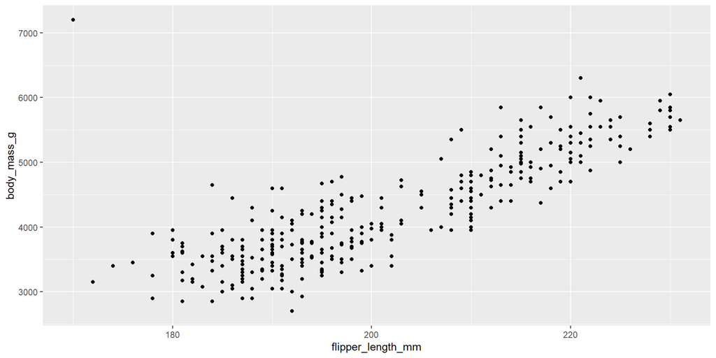

## Ausreisser

**boxplot**

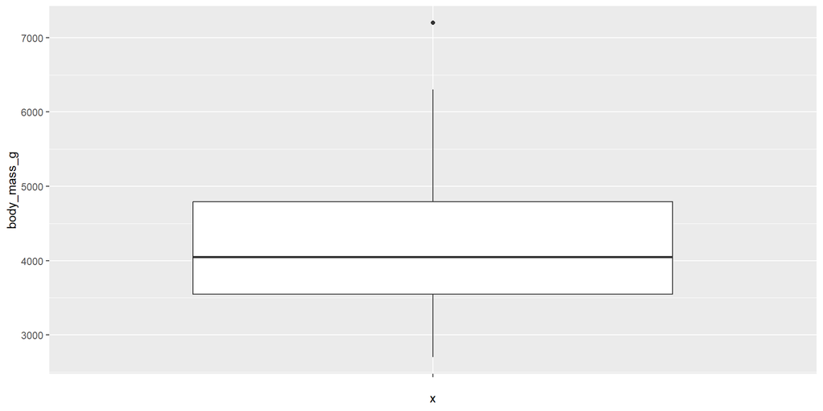

## Skalenreliabilität

- Interne Konsistsenz (Cronbach’s Alpha)

```r
#Mit psych Package
library(psych)

bfi_10_extra <- bfi_10_data |>
  select(bfi_extra_1_r, bfi_extra_2)

alpha(bfi_10_extra, check.keys = TRUE)
```

```
Reliability analysis
Call: alpha(x = bfi_10_extra, check.keys = TRUE)

  raw_alpha std.alpha G6(smc) average_r S/N   ase mean sd median_r
      0.76      0.76    0.62      0.62 3.2 0.085    3  1     0.62

    95% confidence boundaries
         lower alpha upper
Feldt      0.5  0.76  0.89
Duhachek   0.6  0.76  0.93

 Reliability if an item is dropped:
              raw_alpha std.alpha G6(smc) average_r S/N alpha se var.r med.r
bfi_extra_1_r      0.54      0.62    0.38      0.62 1.6       NA     0  0.62
bfi_extra_2        0.71      0.62    0.38      0.62 1.6       NA     0  0.62

 Item statistics
               n raw.r std.r r.cor r.drop mean  sd
bfi_extra_1_r 29  0.89   0.9  0.71   0.62    3 1.1
bfi_extra_2   29  0.92   0.9  0.71   0.62    3 1.2

Non missing response frequency for each item
                 1    2    3    4    5 miss
bfi_extra_1_r 0.07 0.24 0.41 0.17 0.10 0.03
bfi_extra_2   0.10 0.28 0.28 0.21 0.14 0.03
```

## Skalenreliabilität (2)

- Mc Donalds Omega
- Test-Retest Reliabilität 👉 Korrelation zwischen Fragebögen an zwei Messzeitpunkten
- Split-half Reliabilität 👉 Aufteilen des Fragebogens in zwei Hälften und deren Reliabilitäten (z.B. Cronbach‘s Alpha) vergleichen. Möglich mit der Funktion `splitHalf()` aus dem psych Paket.

Mehr Infos dazu: [Psychometrics in R](https://bookdown.org/annabrown/psychometricsR/exercise5.html) & [Björn Walther](https://bjoernwalther.com/cronbachs-alpha-in-r-berechnen/)

## Heute haben wir:

- Wide to long Transformationen gemacht - **You mastered the tidyr!**

[figure not shown]

- Datenqualitätsindikatoren kennengelernt

## Bis nächste Woche

- Muddiest Points Umfrage bis Sonntag 23:55
- Es gibt sonst keine HÜ - nutzt die Zeit verpasstes nachzuholen, schwierige Aspekte noch mal anzuschauen etc.
- Lars kann bei Bedarf kontaktiert werden
- Forum nutzen!

References:

Wickham H (2025). *genzplyr: dplyr but make it bussin fr fr no cap*. R package version 0.0.0.9000, https://github.com/hadley/genzplyr.

Leys, Christophe, Marie Delacre, Youri L. Mora, Daniël Lakens, and Christophe Ley. 2019. “How to Classify, Detect, and Manage Univariate and Multivariate Outliers, with Emphasis on Pre-Registration.” *International Review of Social Psychology* 32 (1). https://doi.org/10.5334/irsp.289.